# Notebook

```python
import importlib
from typing import Dict

import numpy as np
from IPython.core.display import Markdown
from matplotlib import pyplot as plt

from shared.definitions import TuningResult
from shared.ml_config_core import ModelTrainingResult
from shared import pipeline, stats_utils
from shared.ml_config_runner import build_production_model_for_tuning_result
from shared.pipeline import extract_feature_names
from src import data_loader
from shared import graph
from shared import utils
import seaborn as sns
import pandas as pd
import xgboost
```

```python
utils.pandas_config(pd)
utils.plt_config(plt)

sns.set_theme(style="darkgrid", palette="pastel")
plt.style.use("fivethirtyeight")
```

```python
SELECTED_MODEL = "XGBoostTuneF1"
INCLUDE_MODELS = [
    "CatBoostF1",
    "XGBoostTuneF1",
    # "XGBoostTuneLogLoss",
    # "XGBoostTunePRAUC"
]
```

```python
transformed_data = data_loader.load_processed_dataset(sample_size=data_loader.SampleSize.Tiny)
```

```python
print(f"Total Samples Loaded {len(transformed_data)}")
```

```
Total Samples Loaded 5361
```

```python
cv_results_all_models: Dict[str, ModelTrainingResult] = {}

for model_key in INCLUDE_MODELS:
    tuning_result = TuningResult.load_serialized_tuning_result(model_key)

    cv_results = build_production_model_for_tuning_result(tuning_result=tuning_result, df=transformed_data)
    cv_results_all_models[model_key] = cv_results

    ModelTrainingResult.serialize_model(cv_results, model_key)
```

```
CatBoostF1: 8.0 seconds
XGBoostTuneF1: 3.4 seconds
```

```python
if len(cv_results_all_models) == 1:
    cv_results_all_models["DUMMY"] = cv_results_all_models[list(cv_results_all_models.keys())[0]]
```

```python
# cv_results_all_models: Dict[str, ModelTrainingResult] = {
#     SELECTED_MODEL: cv_results,
#     f"{SELECTED_MODEL}_DUMMY": cv_results
# }
```

```python
# confusion_matrices = {}
#
# for k, v in cv_results_all_models.items():
#     confusion_matrices[k] = (v.cm_data, v.test_data)
#
# confusion_matrix_labels = ["Paid Off", "Default"]
# confusion_matrix_axis_label = ""
```

```python
# cv_results.test_data

#TODO: we need to export matrix_data (cm_data) from the test model
```

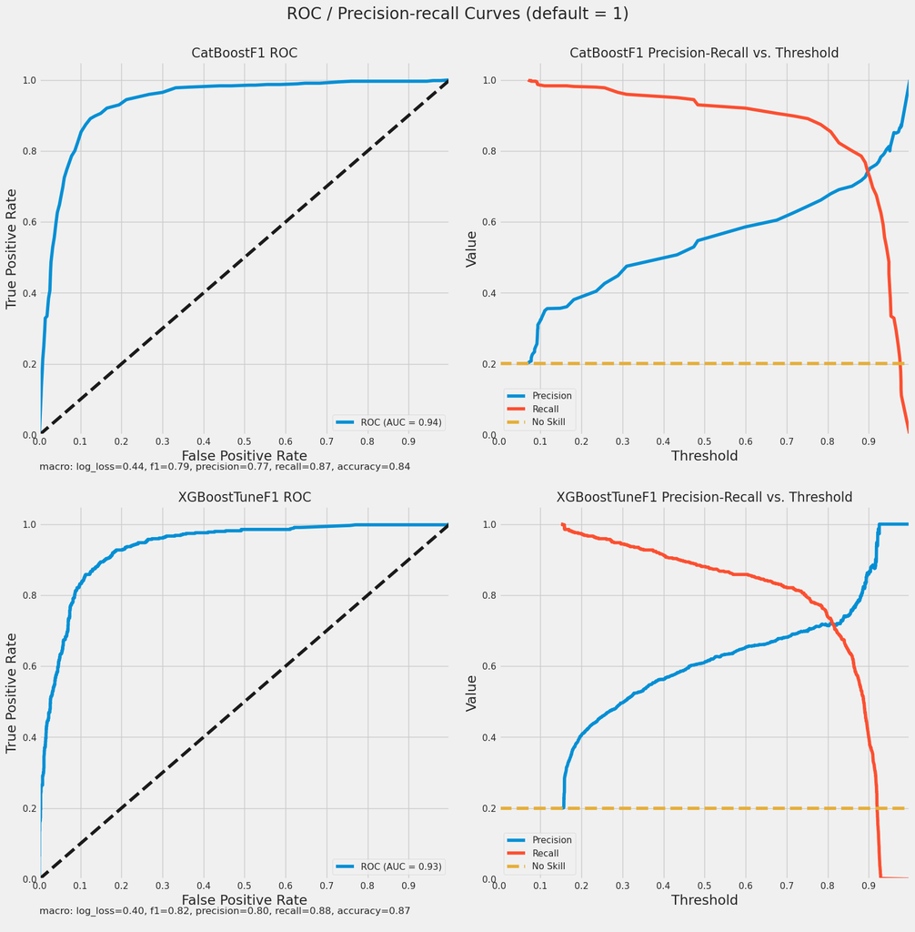

```python
importlib.reload(graph)

graph.roc_precision_recal_grid_plot(cv_results_all_models, add_fbeta_25=True)
```

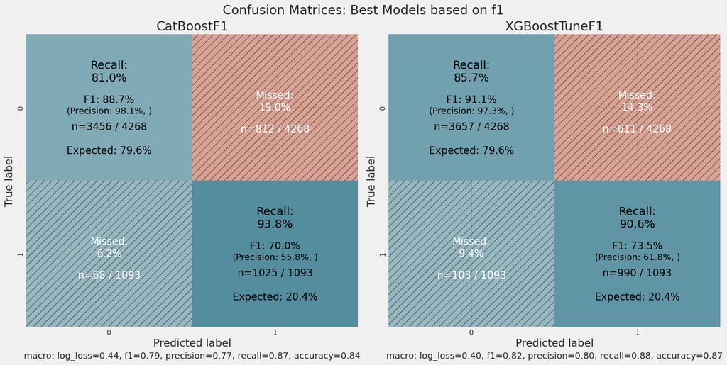

```python
%matplotlib inline

importlib.reload(graph)

n = len(cv_results_all_models)
columns = 2
rows = (n + 1) // columns
height = 8
width = height * columns

fig, axes = plt.subplots(
    rows, columns, figsize=(width, height * rows), constrained_layout=True
)
plt.suptitle("Confusion Matrices: Best Models based on f1", fontsize=20)

axes_flat = axes.flatten()
for i, model_key in enumerate(cv_results_all_models.keys()):
    graph.confusion_matrix_plot_v2(
        cv_results_all_models[model_key].cm_data,
        title=model_key,
        annotations=graph.make_annotations(cv_results_all_models[model_key].cv_metrics),
        ax=axes_flat[i],
    )

# Hide any unused axes
for j in range(i + 1, len(axes_flat)):
    axes_flat[j].axis("off")

plt.show()
```

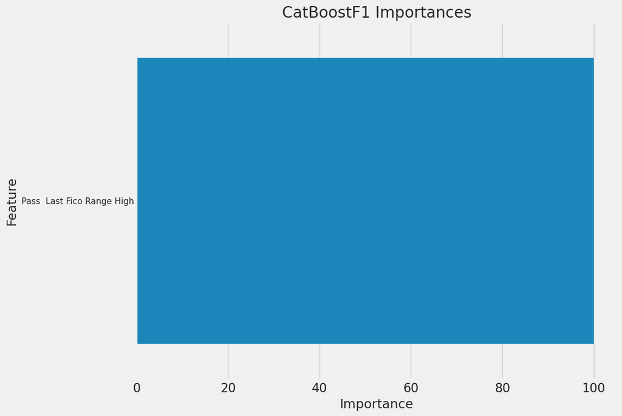

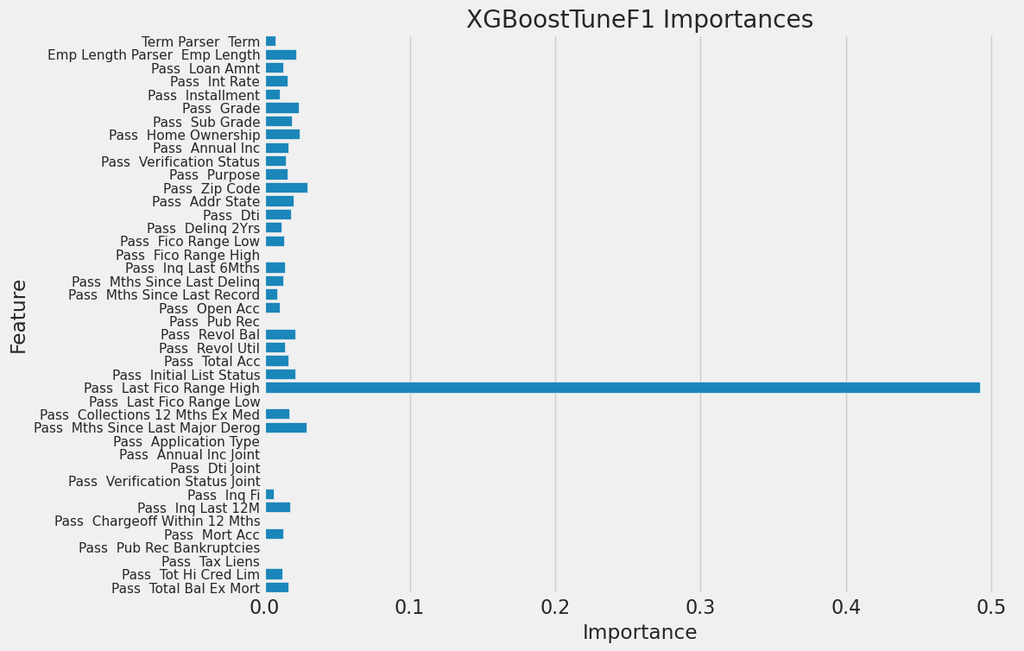

```python
for model_key in cv_results_all_models.keys():
    model_config = cv_results_all_models[model_key]

    #TODO: importances are missing
    #TODO: need to make importances work with with feature transformers since
    importances = model_config.test_data.feature_importances

    #TODO: implement feature importances setting inot the pipeline itself instead of having to do it manually here:
    model = model_config.test_data.test_model.named_steps['model']
    feature_importances = model.feature_importances_

    feature_names = extract_feature_names(model_config.test_data.test_model,
                                          transformed_data.sample(10, random_state=42))
    assert len(feature_names) == len(feature_importances), "The length of feature names and importances does not match."
    # feature_importances = zip(feature_names, feature_importances)
    feature_importances = pd.DataFrame({"Feature": feature_names, "Importance": feature_importances})

    graph.render_feature_importances_chart(
        feature_importances=feature_importances,
        title=f"{model_key} Importances",
    )

    # model = model_config.test_data.test_model.named_steps["model"]
    # x_test = model_config.test_data.x_test
    # # labels, x_test = pipeline._get_features_labels(model_config.test_data.x_test)
    # # x_test = model_config.test_data.x_test
    # x_train = model_config.test_data.x_train
    # y_test = model_config.test_data.y_test
    #
    # labels['target__loan_status'] = y_test

    # if "Linear" in model_key:
    #     explainer = shap.LinearExplainer(model, x_train)
    # elif "SVM" in model_key:
    #     continue
    #     X_background_sampled = shap.sample(x_train, 100)
    #     explainer = shap.KernelExplainer(model.predict, X_background_sampled)
    #
    # elif "Boost" in model_key:
    #     booster_model = model.get_booster()
    #     shap_values = booster_model.predict(
    #         xgboost.DMatrix(x_test, enable_categorical=True), pred_contribs=True
    #     )
    #
    #     shap_values = shap_values[:, :-1]
    #     shap.summary_plot(
    #         shap_values,
    #         features=x_test,
    #         feature_names=x_test.columns,
    #         plot_size=(12, 8),
    #     )
    #
    # else:
    #     try:
    #         explainer = shap.Explainer(model)
    #     except:
    #         continue
    #
    # try:
    #     shap_values = explainer.shap_values(x_train)
    #     shap.summary_plot(shap_values, x_train, plot_size=(32, 7))
    # except:
    #     pass
```

```python
transformed_data["target__loan_status"]
```

```
1233152    0.0
461729     0.0
738295     0.0
390716     0.0
350813     0.0
          ...
701647     1.0
1093222    0.0
1231982    0.0
143267     1.0
208225     1.0
Name: target__loan_status, Length: 5361, dtype: float64
```

```python
# Step 1: Calculate value counts and proportions
value_counts = transformed_data["pass__grade"].value_counts()
proportions = value_counts / value_counts.sum()

# Step 2: Calculate the ratio of target__loan_status being 1 for each grade
loan_status_ratio = transformed_data.groupby('pass__grade')['target__loan_status'].mean()

# Step 3: Create DataFrame combining Counts, Proportions, and Loan Status Ratio
df = pd.DataFrame({
    'Counts': value_counts,
    'Proportion': proportions,
    'Loan_Status_Ratio': loan_status_ratio
})

# Step 4: Sort the DataFrame based on the index (grade) alphabetically
source_df_grades_summary = df.sort_index()
source_df_grades_summary
```

|  | Counts | Proportion | Loan_Status_Ratio |
| --- | --- | --- | --- |
| A | 922 | 0.171983 | 0.069414 |
| B | 1601 | 0.298638 | 0.132417 |
| C | 1494 | 0.278679 | 0.223561 |
| D | 787 | 0.146801 | 0.312579 |
| E | 388 | 0.072375 | 0.384021 |
| F | 125 | 0.023317 | 0.504000 |
| G | 44 | 0.008207 | 0.568182 |

```python
sorted_grades = np.sort(transformed_data["pass__grade"].unique())
sorted_grades
```

```
array(['A', 'B', 'C', 'D', 'E', 'F', 'G'], dtype=object)
```

```python
# Calculate the length of each section
num_grades = len(sorted_grades)
section_length = 1.0 / num_grades
palette = sns.color_palette("YlOrRd", n_colors=len(sorted_grades) - 1)

start_color = "grey"
end_color = "red"

# Prepend grey to the palette
colors = [start_color] + palette

log_scale = np.log(range(2, num_grades + 2))  # Change here, start range at 2
scale_factor = 1 / log_scale.sum()
cumulative_log_scale = np.cumsum(np.log(range(2, num_grades + 2)))  # Cumulative sum of log values
normalized_log_scale = cumulative_log_scale / cumulative_log_scale[-1]  # Normalize to max out at 1

# Generate sections
sections = []
start = 0
for i, grade in enumerate(sorted_grades):
    if i == 0:
        start = 0
    else:
        start = normalized_log_scale[i - 1]
    end = normalized_log_scale[i]
    section = {
        "label": f"{grade} Grade",
        "start": start,
        "end": end,
        "color": colors[i],
        "description": "",  # Optional: Add descriptions as needed
    }
    sections.append(section)
sections
```

```
[{'label': 'A Grade',
  'start': 0,
  'end': 0.06536286053488224,
  'color': 'grey',
  'description': ''},
 {'label': 'B Grade',
  'start': 0.06536286053488224,
  'end': 0.16896054342253738,
  'color': (0.9994925028835063, 0.9192618223760093, 0.6061361014994233),
  'description': ''},
 {'label': 'C Grade',
  'start': 0.16896054342253738,
  'end': 0.29968626449230185,
  'color': (0.996078431372549, 0.8065974625144174, 0.41494809688581313),
  'description': ''},
 {'label': 'D Grade',
  'start': 0.29968626449230185,
  'end': 0.4514541267304494,
  'color': (0.9944329104190696, 0.6371549404075355, 0.2717108804306036),
  'description': ''},
 {'label': 'E Grade',
  'start': 0.4514541267304494,
  'end': 0.6204146701529868,
  'color': (0.9898808150711266, 0.40955017301038066, 0.19432525951557092),
  'description': ''},
 {'label': 'F Grade',
  'start': 0.6204146701529868,
  'end': 0.8039114183953532,
  'color': (0.9186466743560169, 0.16113802383698578, 0.1257362552864283),
  'description': ''},
 {'label': 'G Grade',
  'start': 0.8039114183953532,
  'end': 1.0,
  'color': (0.7604613610149943, 0.013194925028835056, 0.14394463667820068),
  'description': ''}]
```

```python
# TODO: how to optimize thresholds for grades?
```

```python
cm_target_model_key = "XGBoostTunePRAUC"
cm_target_model = cv_results_all_models[cm_target_model_key]

target_cm_data = cm_target_model.cm_data
target_cm_data.probabilities
```

[output not shown]

### Calculating Probability Thresholds

If we're using our binary classification model to assign grades to loans based on default probabilities we can't directly try to predict the grades from the source dataset.

Basically what we can do is to use the source dataset as a baseline and try to determine whether our model can outperform the method the Lending Club is using for determine grades, we'll try to maintain the same ratio of grades while trying to minimize the default risk for loans included in top grades (basically we want to make sure that's the spread of default risk between grades is maximized i.e. default risk for grade A is as close to 0% and for grade F as close to 100% as possible while also ensuring that the risk increased with continuously with grade)

```python
# Sort probabilities for cumulative proportion mapping
target_cm_data_sorted = target_cm_data.probabilities.sort_values(by=1).reset_index(drop=True)

# Calculate cumulative proportions for thresholds
source_df_grades_summary['Cumulative'] = source_df_grades_summary['Proportion'].cumsum()

# Initialize sections list
sections = []

palette = sns.color_palette("YlOrRd", n_colors=len(sorted_grades) - 1)

start_color = "grey"
end_color = "red"

# Prepend grey to the palette
colors = [start_color] + palette

i = 0

# Find thresholds in target_cm_data that match cumulative proportions
for grade, row in source_df_grades_summary.iterrows():
    if grade == source_df_grades_summary.index[0]:
        start = 0.0
    else:
        start = target_cm_data_sorted[1].quantile(previous_cumulative)

    end = target_cm_data_sorted[1].quantile(row['Cumulative'])
    sections.append({
        "label": f"{grade} Grade",
        "start": start,
        "end": end,
        # Assign colors and descriptions as needed
        "color": colors[i],
        "description": ""
    })
    i = i + 1
    previous_cumulative = row['Cumulative']

# Example output
for section in sections:
    print(section)
```

[output not shown]

```python
# Assuming source_df_grades_summary and target_cm_data are already defined

# Sort probabilities for cumulative proportion mapping
target_cm_data_sorted = target_cm_data.probabilities.sort_values(by=1).reset_index(
    drop=True)  # Modified if using a different DataFrame structure

# Calculate cumulative proportions for thresholds
source_df_grades_summary['Cumulative'] = source_df_grades_summary['Proportion'].cumsum()

# Initialize sections list
sections = []

palette = sns.color_palette("YlOrRd", n_colors=len(
    source_df_grades_summary) - 4)  # -4 because merging E, F, G into one and excluding from palette count

start_color = "grey"
# Prepend grey to the palette
colors = [start_color] + palette + ["red"]  # Ensure "red" is used for the merged EFG section

i = 0
previous_cumulative = 0  # Initialize previous_cumulative

efg_weights = source_df_grades_summary.loc['E':'G', 'Counts']
efg_risks = source_df_grades_summary.loc['E':'G', 'Loan_Status_Ratio']
weighted_avg_risk_efg = np.average(efg_risks, weights=efg_weights)

# Find thresholds in target_cm_data that match cumulative proportions
for grade, row in source_df_grades_summary.iterrows():
    if grade == source_df_grades_summary.index[0]:
        start = 0.0
    else:
        start = target_cm_data_sorted[1].quantile(previous_cumulative)  # Ensure column name is a string

    end = target_cm_data_sorted[1].quantile(row['Cumulative'])

    # Modification to merge sections E, F, G
    if grade == "E":
        continue  # Skip E and F, but prepare to merge them with G
    elif grade == "F":
        continue  # Skip F, but prepare to merge with G
    elif grade == "G":  # When reaching G, adjust label and color for merged section
        label = "E-F-G Grade"
        color = "red"  # Assign red or any color intended for the merged section
    else:
        label = f"{grade} Grade"
        color = colors[i]

        # Within the loop, adjust the description field
    if grade == "G":  # Adjusting this if block to include the weighted average calculation
        description = f"Expected D. R.: {weighted_avg_risk_efg:.1%}"
    else:
        description = f"Expected D. R.: {row['Loan_Status_Ratio']:.1%}"

    sections.append({
        "label": label,
        "start": start,
        "end": end,
        # Assign colors and descriptions as needed
        "color": color,
        "description": description,
    })
    if grade != "G":  # Increment i only if not processing E-F-G (since they're merged)
        i += 1
    previous_cumulative = row['Cumulative']
sections[-1]["end"] = 1.0
sections
```

[output not shown]

```python
importlib.reload(stats_utils)
importlib.reload(graph)
summary_desc = "The chart shows the  performance of the if only individual with stroke Prob. > T are selected. Additionally the overlay indicates the number of people whose predicted P is in an given range. The overlays can be used to selected the most at risk individual based on the probability predicted for them"

# sections = [
#     {
#         "label": "Low Risk",
#         "start_data": 0,
#         "start": 0,
#         "end": 0.35,
#         "color": "grey",
#         "inverse": True,
#         "description": "(P < 0.5)",
#     },
#     {
#         "label": "Elevated Risk",
#         "start": 0.35,
#         "end": 0.6,
#         "color": "yellow",
#         "description": "",
#     },
#     {
#         "label": "Medium Risk",
#         "start": 0.6,
#         "end": 0.75,
#         "color": "orange",
#         "description": "",
#     },
#     {
#         "label": "High Risk",
#         "start": 0.75,
#         "end": 1.0,
#         "end_data": 1,
#         "color": "red",
#         "description": "",
#     },
# ]

graph.plot_threshold_metrics_v2(
    target_cm_data,
    0,
    1,
    sections=sections,

    model_name=cm_target_model_key,
    class_pos=1,
    include_vars=["f1", "precision", "recall"],
    show_threshold_n=True,
    log_x=True
)
display(Markdown(summary_desc))
```

[output not shown]

```python
transformed_data
```

```python
def calculate_loan_portfolio_metrics(data):
    """
    Calculate loan metrics including total loan amount, total interest paid, total return percentage, and total loss.

    Args:
    - data: DataFrame with columns 'target__loan_status', 'pass__loan_amnt', and 'pass__int_rate'

    Returns:
    - DataFrame: A DataFrame containing the calculated metrics.
    """
    data = data.copy()
    # Total Loan Amount
    total_loan_amount = data['pass__loan_amnt'].sum()

    # Total Loss - Sum of loan amounts for loans that defaulted
    total_loss = data.loc[data['target__loan_status'] == 1, 'pass__loan_amnt'].sum()

    # Total Interest Paid - Only from loans that did not default
    data['interest_paid'] = data.apply(
        lambda x: (x['pass__loan_amnt'] * x['pass__int_rate'] / 100) if x['target__loan_status'] == 0 else 0, axis=1)
    total_interest_paid = data['interest_paid'].sum()

    # Expected Total Interest - If no loans defaulted
    data['expected_interest'] = data['pass__loan_amnt'] * data['pass__int_rate'] / 100
    expected_total_interest = data['expected_interest'].sum()

    # Total Return % - (Total Interest Paid / Total Loan Amount) * 100
    total_return_percent = (total_interest_paid / total_loan_amount) * 100

    # Expected Return % - (Expected Total Interest / Total Loan Amount) * 100
    expected_return_percent = (expected_total_interest / total_loan_amount) * 100

    # Compile metrics into a DataFrame
    metrics_df = pd.DataFrame({
        "Total Loan Amount": [total_loan_amount],
        "Total Interest Paid": [total_interest_paid],
        "Expected Return %": [expected_return_percent],
        "Total Return %": [total_return_percent],
        "Total Loss": [total_loss]
    })

    return metrics_df
```

```python
calculate_loan_portfolio_metrics(transformed_data)
```

[output not shown]

```python
# def format_millions(value):
#     """
#     Helper function to format the value as millions with 4 decimal places.
#     """
#     if value is not None:  # Check to avoid formatting None values
#         return f"{value / 1_000_000:.4f}M"
#     return value
#
# def estimate_financial_improvement(data, predictions):
#     """
#     Estimate financial improvement by comparing actual financial metrics to hypothetical
#     scenarios where loans predicted to default were not issued.
#
#     Args:
#     - data: DataFrame with actual loan data, columns 'target__loan_status', 'pass__loan_amnt', and 'pass__int_rate'.
#     - predictions: Series or list containing model predictions corresponding to the data.
#
#     Returns:
#     - DataFrame: A DataFrame containing both actual and hypothetical financial metrics.
#     """
#     # Integrate predictions into the data DataFrame
#     data_with_predictions = data.copy()
#     data_with_predictions['predictions'] = predictions
#
#     # Actual scenario calculations
#     data['interest_paid'] = data.apply(lambda x: (x['pass__loan_amnt'] * x['pass__int_rate'] / 100) if x['target__loan_status'] == 0 else 0, axis=1)
#     total_loan_amount_actual = data['pass__loan_amnt'].sum()
#     total_interest_paid_actual = data['interest_paid'].sum()
#     total_loss_actual = data.loc[data['target__loan_status'] == 1, 'pass__loan_amnt'].sum()
#     total_return_percent_actual = (total_interest_paid_actual / total_loan_amount_actual) * 100
#
#     # Hypothetical scenario: Exclude loans predicted to default
#     hypothetical_data = data_with_predictions[data_with_predictions['predictions'] == 0]
#     hypothetical_data['interest_paid'] = hypothetical_data['pass__loan_amnt'] * hypothetical_data['pass__int_rate'] / 100
#     total_loan_amount_hypo = hypothetical_data['pass__loan_amnt'].sum()
#     total_interest_paid_hypo = hypothetical_data['interest_paid'].sum()
#     total_loss_hypo = hypothetical_data.loc[hypothetical_data['target__loan_status'] == 1, 'pass__loan_amnt'].sum()
#     total_return_percent_hypo = (total_interest_paid_hypo / total_loan_amount_hypo) * 100 if total_loan_amount_hypo else 0
#
#     # Calculate the losses avoided and interest lost by not issuing loans predicted to default
#     losses_avoided = total_loss_actual - total_loss_hypo
#     interest_lost = total_interest_paid_actual - total_interest_paid_hypo
#
#     improvement_metrics = {
#         "Total Loan Amount": [total_loan_amount_actual, total_loan_amount_hypo],
#         "Total Interest Paid": [total_interest_paid_actual, total_interest_paid_hypo],
#         "Total Return %": [total_return_percent_actual, total_return_percent_hypo],
#         "Total Loss": [total_loss_actual, total_loss_hypo],
#         "Losses Avoided": [None, losses_avoided],
#         "Interest Lost": [None, interest_lost],
#     }
#
#     # Creating DataFrame from the dictionary
#     # improvement_df = pd.DataFrame(improvement_metrics, index=["Actual", "Hypothetical"]).T
#         # Creating DataFrame from the dictionary
#     improvement_df = pd.DataFrame(improvement_metrics, index=["Actual", "Hypothetical"]).T
#
#     # Apply formatting based on the row label
#     for row_label, row_values in improvement_df.iterrows():
#         if row_label == "Total Return %":
#             improvement_df.loc[row_label] = row_values.apply(lambda x: f"{x:.2f}%" if pd.notnull(x) else None)
#         else:
#             improvement_df.loc[row_label] = row_values.apply(lambda x: f"{x / 1_000_000:.4f}M" if pd.notnull(x) else None)
#
#     return improvement_df
def estimate_financial_improvement(data, predictions):
    """
    Estimate financial improvement by comparing actual financial metrics to hypothetical
    scenarios where loans predicted to default were not issued. Values requiring conversion
    to millions are converted upfront.

    Args:
    - data: DataFrame with actual loan data, including 'target__loan_status', 'pass__loan_amnt', and 'pass__int_rate'.
    - predictions: Series or list containing model predictions corresponding to the data.

    Returns:
    - DataFrame: A DataFrame containing both actual and hypothetical financial metrics, with appropriate formatting.
    """
    # Integrate predictions into the data DataFrame
    data_with_predictions = data.copy()
    data_with_predictions['predictions'] = predictions

    # Calculations for actual scenario
    total_loan_amount_actual = data['pass__loan_amnt'].sum() / 1_000_000  # Convert to millions
    total_interest_paid_actual = data.apply(
        lambda x: (x['pass__loan_amnt'] * x['pass__int_rate'] / 100) if x['target__loan_status'] == 0 else 0,
        axis=1).sum() / 1_000_000  # Convert to millions
    total_loss_actual = data.loc[data[
                                     'target__loan_status'] == 1, 'pass__loan_amnt'].sum() / 1_000_000  # Convert to millions
    total_return_percent_actual = (total_interest_paid_actual * 1_000_000 / (
            total_loan_amount_actual * 1_000_000)) * 100  # Recalculate to correct percentage

    # Calculations for hypothetical scenario
    hypothetical_data = data_with_predictions[data_with_predictions['predictions'] == 0]
    total_loan_amount_hypo = hypothetical_data['pass__loan_amnt'].sum() / 1_000_000  # Convert to millions
    total_interest_paid_hypo = hypothetical_data.apply(lambda x: x['pass__loan_amnt'] * x['pass__int_rate'] / 100,
                                                       axis=1).sum() / 1_000_000  # Convert to millions
    total_loss_hypo = hypothetical_data.loc[hypothetical_data[
                                                'target__loan_status'] == 1, 'pass__loan_amnt'].sum() / 1_000_000  # Convert to millions
    total_return_percent_hypo = (total_interest_paid_hypo * 1_000_000 / (
            total_loan_amount_hypo * 1_000_000)) * 100  # Recalculate to correct percentage if total_loan_amount_hypo > 0 else 0

    # Calculate the losses avoided and interest lost by not issuing loans predicted to default
    losses_avoided = (total_loss_actual - total_loss_hypo)  # Already in millions
    interest_lost = (total_interest_paid_hypo - total_interest_paid_actual)  # Already in millions

    # Total Applications Accepted
    total_applications_actual = len(data)
    total_applications_hypo = len(hypothetical_data)

    # Metric dictionary with conversions applied where necessary
    improvement_metrics = {
        "Total Loan Amount": [f"{total_loan_amount_actual:.4f}M", f"{total_loan_amount_hypo:.4f}M"],
        "Total Interest Paid": [f"{total_interest_paid_actual:.4f}M", f"{total_interest_paid_hypo:.4f}M"],
        "Total Return %": [f"{total_return_percent_actual:.2f}%", f"{total_return_percent_hypo:.2f}%"],
        "Total Loss": [f"{total_loss_actual:.4f}M", f"{total_loss_hypo:.4f}M"],
        "Losses Avoided": [None, f"{losses_avoided:.4f}M"],
        "Interest Lost": [None, f"{interest_lost:.4f}M"],
        "Total Applications Accepted": [total_applications_actual, total_applications_hypo],
    }

    # Creating DataFrame from the dictionary
    improvement_df = pd.DataFrame(improvement_metrics, index=["Actual", "Hypothetical"]).T

    return improvement_df
```

```python
estimate_financial_improvement(transformed_data, target_cm_data.predictions)
```

[output not shown]

### Limitations

Therefore, to provide a more accurate estimate and to figure out whether our model would actually be useful we'd need to incorporate the actual amounts received etc.

TODO: consider doing this (we'd just need to use the appropriate column from the df)

```python
print(len(transformed_data))
print(len(target_cm_data.predictions))
```

[output not shown]

```python
# temp_df = transformed_data.copy()
#
# temp_df["predicted"] = target_cm_data.predictions
#
# temp_df[["target__loan_status", "predicted"]]
```

```python
print(temp_df["predicted"].sum())
print(temp_df["target__loan_status"].sum())
```

[output not shown]